# Practice Week 2

Hugo van den Belt

2024-12-16

# Uncertainty

## Bootstraps w/ python

I do not fully understand why we get a different distribution when we draw n observations (with replacement) from a distribution n observations. Shouldn’t we just get the same distribution? I asked Claude AI to generate the following python code (python because I understand it better). I added an input function for the number of desired bootstraps.

Edit: Nevermind, input functions don’t work in md files (just like in IPYNB)

```python
import numpy as np
from collections import Counter

# Set a random seed for reproducibility
np.random.seed(42)

# Create our original sample - let's use 5 numbers for clarity
original_sample = np.array([10, 20, 30, 40, 50, 50, 50])
print("Original sample:", original_sample)
```

```
## Original sample: [10 20 30 40 50 50 50]
```

```python
# Create several bootstrap samples
n_bootstraps = 5
sample_size = len(original_sample)

print("\nLet's look at 5 different bootstrap samples:")
```

```
##
## Let's look at 5 different bootstrap samples:
```

```python
for i in range(n_bootstraps):
    # Generate one bootstrap sample
    bootstrap_sample = np.random.choice(original_sample, size=sample_size, replace=True)

    # Count how many times each value appears
    value_counts = Counter(bootstrap_sample)

    # Create a formatted string showing counts
    counts_str = ", ".join(f"{val}({count}x)" for val, count in sorted(value_counts.items()))

    print(f"\nBootstrap sample {i+1}:")
    print(f"Values (count): {counts_str}")
    print(f"Missing values: {set(original_sample) - set(bootstrap_sample)}")
```

```
##
## Bootstrap sample 1:
## Values (count): 30(1x), 40(1x), 50(5x)
## Missing values: {np.int64(10), np.int64(20)}
##
## Bootstrap sample 2:
## Values (count): 20(1x), 30(3x), 50(3x)
## Missing values: {np.int64(40), np.int64(10)}
##
## Bootstrap sample 3:
## Values (count): 20(1x), 30(1x), 40(2x), 50(3x)
## Missing values: {np.int64(10)}
##
## Bootstrap sample 4:
## Values (count): 10(1x), 20(2x), 40(2x), 50(2x)
## Missing values: {np.int64(30)}
##
## Bootstrap sample 5:
## Values (count): 10(2x), 30(2x), 40(1x), 50(2x)
## Missing values: {np.int64(20)}
```

```python
# Let's also look at how often values are missing
print("\nLet's simulate 1000 bootstrap samples and see how often values are missing:")
```

```
##
## Let's simulate 1000 bootstrap samples and see how often values are missing:
```

```python
n_large_simulation = 1000
missing_counts = {val: 0 for val in original_sample}

for _ in range(n_large_simulation):
    bootstrap_sample = np.random.choice(original_sample, size=sample_size, replace=True)
    for val in original_sample:
        if val not in bootstrap_sample:
            missing_counts[val] += 1

print(f"\nNumber of times each value was missing out of {n_large_simulation} samples:")
```

```
##
## Number of times each value was missing out of 1000 samples:
```

```python
for val, count in missing_counts.items():
    percentage = count / n_large_simulation * 100
    print(f"Value {val}: missing in {count} samples ({percentage:.1f}%)")
```

```
## Value 10: missing in 351 samples (35.1%)
## Value 20: missing in 363 samples (36.3%)
## Value 30: missing in 362 samples (36.2%)
## Value 40: missing in 330 samples (33.0%)
## Value 50: missing in 51 samples (5.1%)
```

I wanna see this in a histogram

```python
import matplotlib.pyplot as plt

original_mean = np.mean(original_sample)
bootstrap_means = np.zeros(n_large_simulation)

for i in range(n_large_simulation):
    bootstrap_sample = np.random.choice(original_sample, size=sample_size, replace=True)
    bootstrap_means[i] = np.mean(bootstrap_sample)

# Calculate some statistics about the bootstrap distribution
bootstrap_std = np.std(bootstrap_means)
confidence_interval = np.percentile(bootstrap_means, [2.5, 97.5])

# Create the histogram
plt.figure(figsize=(10, 6))
plt.hist(bootstrap_means, bins=30, density=True, alpha=0.7, color='skyblue')
```

[output not shown]

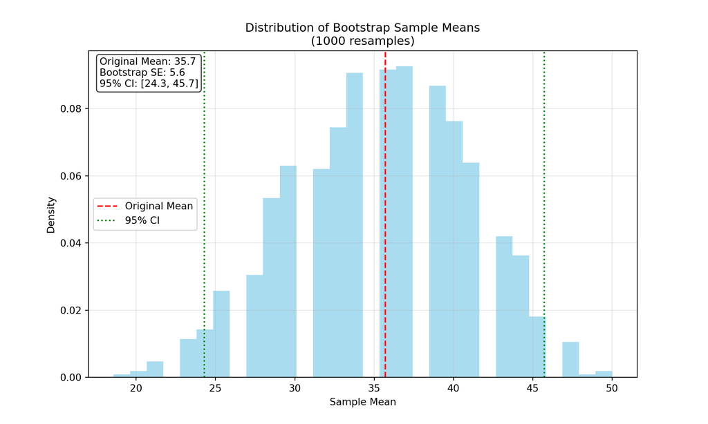

```python
plt.axvline(original_mean, color='red', linestyle='--', label='Original Mean')
plt.axvline(confidence_interval[0], color='green', linestyle=':', label='95% CI')
plt.axvline(confidence_interval[1], color='green', linestyle=':')
plt.title(f'Distribution of Bootstrap Sample Means\n({n_large_simulation} resamples)')
plt.xlabel('Sample Mean')
plt.ylabel('Density')
plt.legend()
# Add text box with statistics
stats_text = f'Original Mean: {original_mean:.1f}\n'
stats_text += f'Bootstrap SE: {bootstrap_std:.1f}\n'
stats_text += f'95% CI: [{confidence_interval[0]:.1f}, {confidence_interval[1]:.1f}]'
plt.text(0.02, 0.98, stats_text, transform=plt.gca().transAxes,
         verticalalignment='top', bbox=dict(boxstyle='round', facecolor='white', alpha=0.8))
plt.grid(True, alpha=0.3)
plt.show()
```

```python
# Print the statistics as well
print("\nSummary Statistics:")
```

```
##
## Summary Statistics:
```

```python
print(stats_text)
```

```
## Original Mean: 35.7
## Bootstrap SE: 5.6
## 95% CI: [24.3, 45.7]
```

After a lot of debugging, this looks pretty. I understand now (I think); because we take the mean of every bootstrap, we get many different possible values for the mean, even though our original data only had a few distinct values. Each bootstrap sample can contain different combinations and frequencies of the original values, and when we average these different combinations, we get new numbers that weren’t in our original dataset. When we have a skew in our original sample, that skew will be present in the bootstrap distribution (but less pronounced)

**Now to Dr. Kapoor’s code** ## Frequentist vs Bootstrap

```r
browser <- read.csv("/Users/hugovandenbelt/Desktop/Data Science Data Sets/web-browsers.csv")
dim(browser)
```

```
## [1] 10000     7
```

```r
head(browser)
```

```
##   id anychildren broadband hispanic  race region spend
## 1  1           0         1        0 white     MW   424
## 2  2           1         1        0 white     MW  2335
## 3  3           1         1        0 white     MW   279
## 4  4           0         1        0 white     MW   829
## 5  5           0         1        0 white      S   221
## 6  6           0         1        0 white     MW  2305
```

the `dim()` functions returns info about the dimensions of a dataset

```r
mean(browser$spend)
```

```
## [1] 1946.439
```

```r
var(browser$spend)/1e4
```

```
## [1] 6461.925
```

```r
sqrt(var(browser$spend)/1e4)
```

```
## [1] 80.3861
```

make a bootstrap algo

```r
B <- 1000
  mub <- c()
  for (b in 1:B){
    samp_b <- sample.int(nrow(browser), replace=TRUE)
    mub <- c(mub, mean(browser$spend[samp_b]))
  }
  sd(mub)
```

```
## [1] 77.43352
```

we get a slightly different estimate every time we run this.

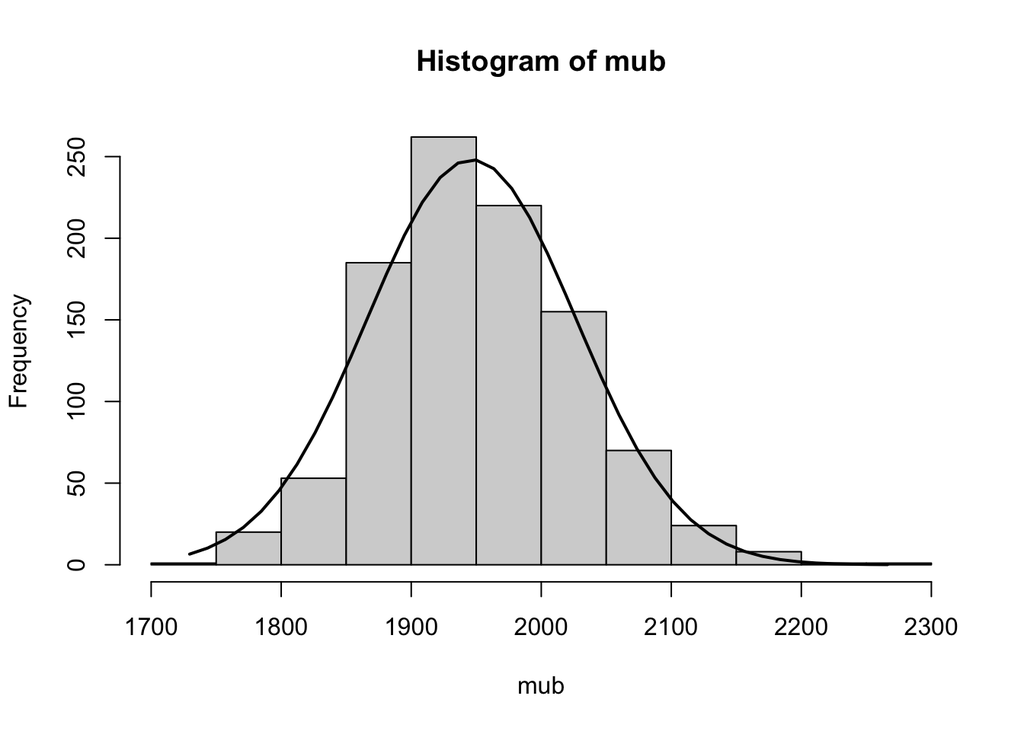

```r
  h <- hist(mub)
  xfit <- seq(min(mub), max(mub), length = 40)
  yfit <- dnorm(xfit, mean = mean(browser$spend), sd = sqrt(var(browser$spend)/1e4))
  yfit <- yfit * diff(h$mids[1:2]) * length(mub)
  #can you explain why we need each term in the last expression?
  lines(xfit, yfit, col = "black", lwd = 2)
```

We need each term in the last expression because the initial yfit values are probability densities that sum to 1, so we multiply by the bin width (diff(h$mids[1:2])) to match the histogram’s scale and by the number of observations (length(mub)) to scale up the density to match the total area of the histogram bars.

```r
  B <- 1000
  betas <- c()
  for (b in 1:1000){
    samp_b <- sample.int(nrow(browser), replace=TRUE)
    reg_b <- glm(log(spend) ~ broadband + anychildren, data=browser[samp_b,])
    betas <- rbind(betas, coef(reg_b))
  }; head(betas, n=5)
```

```
##      (Intercept) broadband anychildren
## [1,]    5.685029 0.5533550  0.08660272
## [2,]    5.657273 0.6274618  0.09245754
## [3,]    5.734759 0.4780077  0.07679602
## [4,]    5.695400 0.5234786  0.08712861
## [5,]    5.673482 0.5561065  0.06907820
```

```r
cov(betas[,"broadband"], betas[,"anychildren"])
```

```
## [1] -8.406471e-05
```

## BH Algorithm

### Example 1

```r
spendy <- glm(log(spend) ~ . -id, data=browser)
round(summary(spendy)$coef,4)
```

```
##             Estimate Std. Error t value Pr(>|t|)
## (Intercept)   5.8643     0.1614 36.3425   0.0000
## anychildren   0.0856     0.0337  2.5361   0.0112
## broadband     0.5217     0.0437 11.9332   0.0000
## hispanic     -0.1820     0.0423 -4.3036   0.0000
## raceblack    -0.2470     0.1756 -1.4071   0.1594
## raceother    -0.4140     0.3143 -1.3172   0.1878
## racewhite    -0.2069     0.1522 -1.3594   0.1740
## regionNE      0.2559     0.0514  4.9807   0.0000
## regionS       0.0056     0.0437  0.1285   0.8977
## regionW       0.1753     0.0506  3.4651   0.0005
```

rewrote the code a bit so it actually outputs the graph

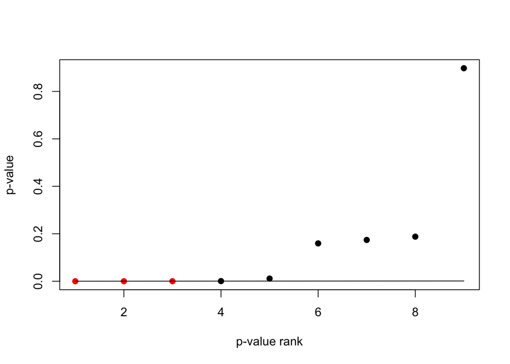

```r
pval <- summary(spendy)$coef[-1, "Pr(>|t|)"]  # this reemoves the intercept p-value
pvalrank <- rank(pval)
reject <- pval < (0.001/9)*pvalrank
plot(pvalrank, pval, ylab="p-value", xlab="p-value rank", pch=19, col=ifelse(reject, "red", "black"))
lines(pvalrank, (0.001/9)*pvalrank)
```

### Example 2

```r
SC <- read.csv("/Users/hugovandenbelt/Desktop/Data Science Data Sets/semiconductor.csv")
dim(SC)
```

```
## [1] 1477  201
```

```r
full <- glm(FAIL ~ ., data=SC, family=binomial) # the dot makes you include all the variables in the dataset
```

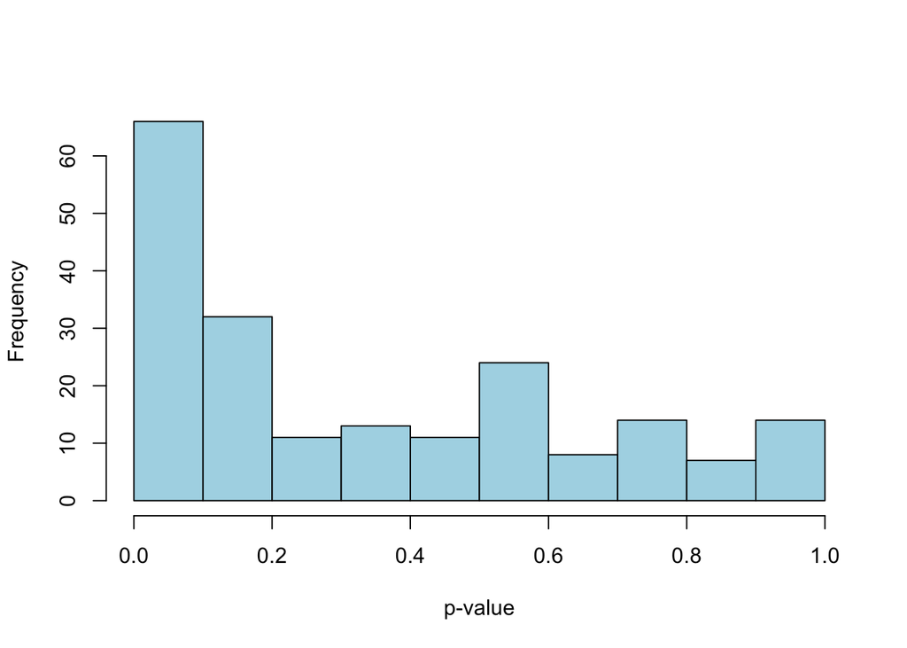

```r
pvals <- summary(full)$coef[-1,4] #-1 to drop the intercept
hist(pvals, xlab="p-value", main="", col="lightblue")#looks like we have some
```

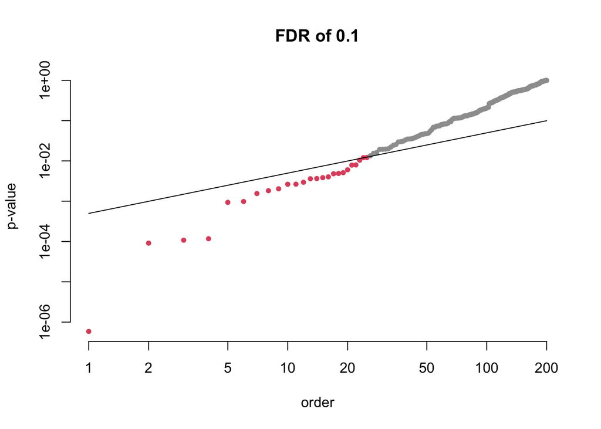

```
## [1] 0.01217043
```

```r
fdr_cut <- function(pvals, q){
  pvals <- sort(pvals[!is.na(pvals)])
  N <- length(pvals)
  k <- rank(pvals, ties.method="min")
  alpha <- max(pvals[ pvals<= (q*k/(N+1)) ])

  plot(pvals, log="xy", xlab="order", main=sprintf("FDR of %g",q),
   ylab="p-value", bty="n", col=c(8,2)[(pvals<=alpha) + 1], pch=20)
  lines(1:N, q*(1:N)/(N+1))

  return(alpha)
}

fdr_cut(pvals, q=0.1)
```

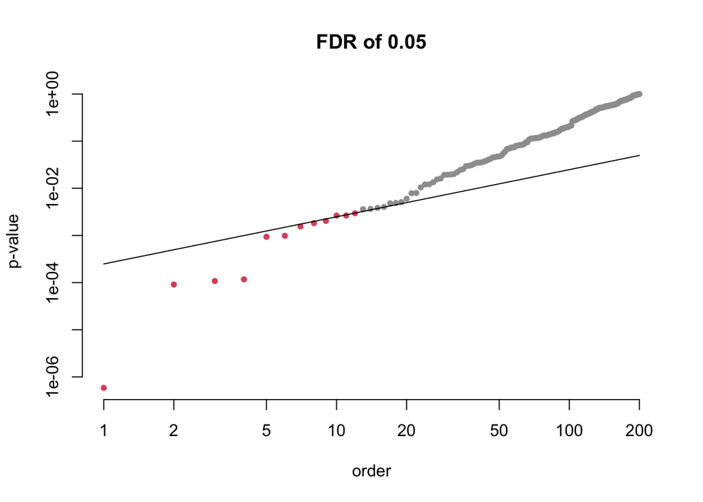

```
## [1] 0.002951738
```

```r
fdr_cut(pvals, q=0.05)
```

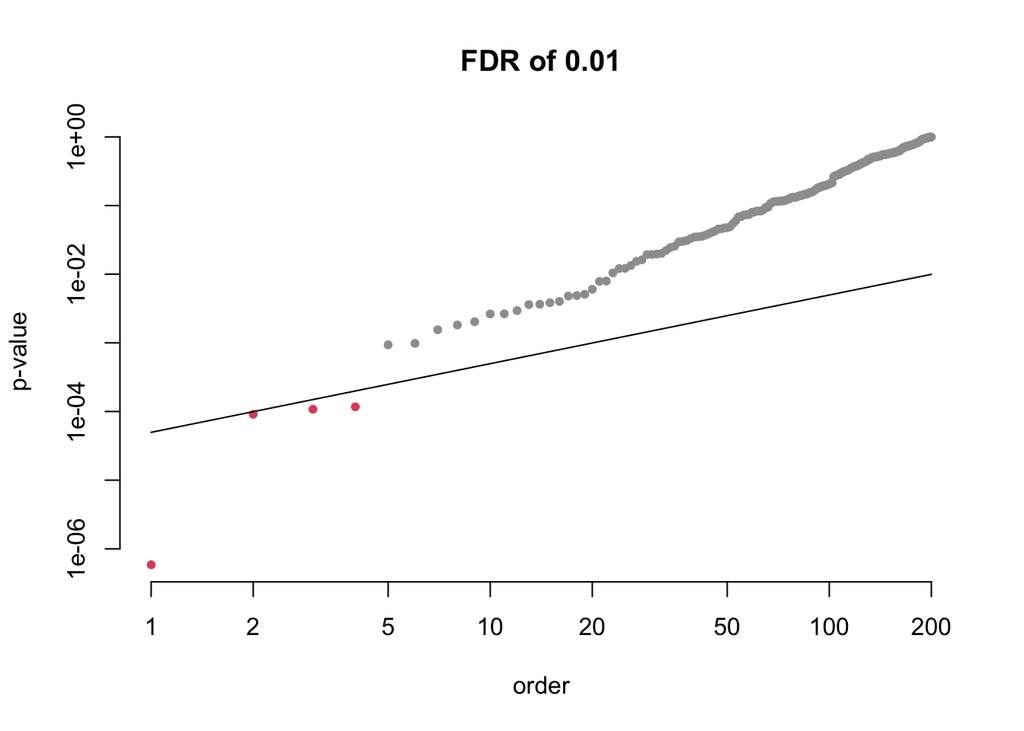

```
## [1] 0.0001171567
```

```r
fdr_cut(pvals, q=0.01)
```

The choice of p-value matters a lot; with q=0.01 there’s only 4 significant coefficients left.